# Prediction of movies popularity

Shwetha Krishna

February 22, 2019

# The purpose of this project is to develop mutliple linear regression model to analyze the factors that will make a movie popular. The dataset contains the information that are extracted from IMDB for random sample movies. For popularity we are going to measure the audience_score as an output variable and the attributes will be the type of movie, genre, runtime, imdb rating, imdb number of votes, critics rating, critics score, audience rating, Oscar awards obtained (actor, actress, director and picture).

# if all these attributes are related significantly then we can find the popularity of movie.

# Load packages

```r
library(ggplot2)
library(dplyr)
library(statsr)
library(gridExtra)
library(corrplot)
```

# Load the data

```r
mydata <- load("C://Users//Shwetha Krishna//Downloads//movies.RData")
```

```r
movies_new <- movies %>% select(title, title_type, genre, runtime, imdb_rating, imdb_num_votes, critics_rating, critics_score, audience_rating, audience_score, best_pic_win, best_actor_win, best_actress_win, best_dir_win)

str(movies_new)
```

```
## Classes 'tbl_df', 'tbl' and 'data.frame':    651 obs. of  14 variables:
##  $ title           : chr  "Filly Brown" "The Dish" "Waiting for Guffman" "The Age of Innocence" ...
##  $ title_type      : Factor w/ 3 levels "Documentary",..: 2 2 2 2 2 1 2 2 1 2 ...
##  $ genre           : Factor w/ 11 levels "Action & Adventure",..: 6 6 4 6 7 5 6 6 5 6 ...
##  $ runtime         : num  80 101 84 139 90 78 142 93 88 119 ...
##  $ imdb_rating     : num  5.5 7.3 7.6 7.2 5.1 7.8 7.2 5.5 7.5 6.6 ...
##  $ imdb_num_votes  : int  899 12285 22381 35096 2386 333 5016 2272 880 12496 ...
##  $ critics_rating  : Factor w/ 3 levels "Certified Fresh",..: 3 1 1 1 3 2 3 3 2 1 ...
##  $ critics_score   : num  45 96 91 80 33 91 57 17 90 83 ...
##  $ audience_rating : Factor w/ 2 levels "Spilled","Upright": 2 2 2 2 1 2 2 1 2 2 ...
##  $ audience_score  : num  73 81 91 76 27 86 76 47 89 66 ...
##  $ best_pic_win    : Factor w/ 2 levels "no","yes": 1 1 1 1 1 1 1 1 1 1 ...
##  $ best_actor_win  : Factor w/ 2 levels "no","yes": 1 1 1 2 1 1 1 2 1 1 ...
##  $ best_actress_win: Factor w/ 2 levels "no","yes": 1 1 1 1 1 1 1 1 1 1 ...
##  $ best_dir_win    : Factor w/ 2 levels "no","yes": 1 1 1 2 1 1 1 1 1 1 ...
```

```r
summary(movies_new)
```

```
##     title                  title_type                 genre
##  Length:651         Documentary : 55   Drama             :305
##  Class :character   Feature Film:591   Comedy            : 87
##  Mode  :character   TV Movie    :  5   Action & Adventure: 65
##                                        Mystery & Suspense: 59
##                                        Documentary       : 52
##                                        Horror            : 23
##                                        (Other)           : 60
##     runtime       imdb_rating    imdb_num_votes           critics_rating
##  Min.   : 39.0   Min.   :1.900   Min.   :   180   Certified Fresh:135
##  1st Qu.: 92.0   1st Qu.:5.900   1st Qu.:  4546   Fresh          :209
##  Median :103.0   Median :6.600   Median : 15116   Rotten         :307
##  Mean   :105.8   Mean   :6.493   Mean   : 57533
##  3rd Qu.:115.8   3rd Qu.:7.300   3rd Qu.: 58301
##  Max.   :267.0   Max.   :9.000   Max.   :893008
##  NA's   :1
##  critics_score    audience_rating audience_score  best_pic_win
##  Min.   :  1.00   Spilled:275     Min.   :11.00   no :644
##  1st Qu.: 33.00   Upright:376     1st Qu.:46.00   yes:  7
##  Median : 61.00                   Median :65.00
##  Mean   : 57.69                   Mean   :62.36
##  3rd Qu.: 83.00                   3rd Qu.:80.00
##  Max.   :100.00                   Max.   :97.00
##
##  best_actor_win best_actress_win best_dir_win
##  no :558        no :579          no :608
##  yes: 93        yes: 72          yes: 43
##
##
##
##
##
```

```r
View(movies_new)
```

# Drop missing value

```r
movies_new <- na.omit(movies_new)
```

Split data into train and test

```r
set.seed(2017)
split <- sample(seq_len(nrow(movies_new)), size = floor(0.999 * nrow(movies_new)))
train <- movies_new[split, ]
test <- movies_new[-split, ]
```

# histogram

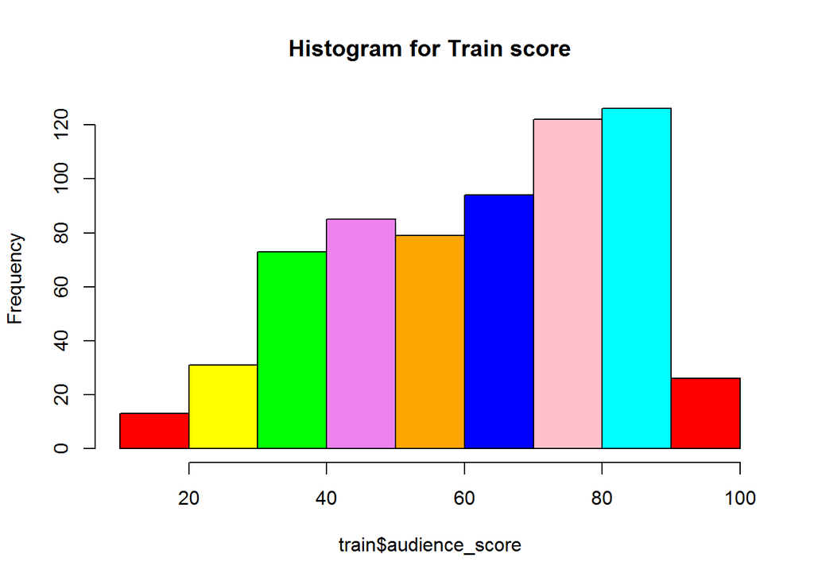

```r
colors = c("red", "yellow", "green", "violet", "orange", "blue", "pink", "cyan")
hist(train$audience_score, col=colors, main = "Histogram for Train score")
```

```r
summary(train$audience_score)
```

```
##    Min. 1st Qu.  Median    Mean 3rd Qu.    Max.
##    11.0    46.0    65.0    62.3    80.0    97.0
```